# Importing Dataset

```python
import pandas as pd
import numpy as np
import seaborn as sns
from kmodes.kmodes import KModes
from sklearn.metrics import completeness_score, homogeneity_score
from sklearn_extra.cluster import KMedoids
from kmodes.kprototypes import KPrototypes
fileName = r'data/in-vehicle-coupon-recommendation.csv'
df = pd.read_csv(fileName, sep=',', na_values = ['?'])
# df=pd.read_csv('in-vehicle-coupon-recommendation.csv')
import matplotlib.pyplot as plt
```

```python
df.isnull().sum() #null values per column
```

```
destination                 0
passanger                   0
weather                     0
temperature                 0
time                        0
coupon                      0
expiration                  0
gender                      0
age                         0
maritalStatus               0
has_children                0
education                   0
occupation                  0
income                      0
car                     12576
Bar                       107
CoffeeHouse               217
CarryAway                 151
RestaurantLessThan20      130
Restaurant20To50          189
toCoupon_GEQ5min            0
toCoupon_GEQ15min           0
toCoupon_GEQ25min           0
direction_same              0
direction_opp               0
Y                           0
dtype: int64
```

First, the car column, which had a huge number of missing values, was dropped.

```python
df2=df.drop('car',axis=1) #drop car
df2.shape
```

```
(12684, 25)
```

Next, rows that had any missing values were dropped. Since the dataset is so large, and replacing these values with mean/mode would make large assumptions, omitting these rows is a safer and better option. Also, we discovered that the variable toCoupon_GEQmin had the same value for every single row, so was unnecessary to include in further analysis. It was also dropped.

```python
df3=df2.dropna() #drop na rows
df3.shape
```

```
(12079, 25)
```

```python
df3.toCoupon_GEQ5min.value_counts()
```

```
1    12079
Name: toCoupon_GEQ5min, dtype: int64
```

```python
df3 = df3.drop('toCoupon_GEQ5min', axis = 1)
```

# Exploratory Data Analysis

```python
dfColumns = []
for i in df3.columns:
    dfColumns.append([i, df3[i].nunique(), df3[i].drop_duplicates().values])
pd.DataFrame(dfColumns, columns = ['Features', 'Unique Number', 'Values'])
```

|  | Features | Unique Number | Values |
| --- | --- | --- | --- |
| 0 | destination | 3 | [No Urgent Place, Home, Work] |
| 1 | passanger | 4 | [Alone, Friend(s), Kid(s), Partner] |
| 2 | weather | 3 | [Sunny, Rainy, Snowy] |
| 3 | temperature | 3 | [55, 80, 30] |
| 4 | time | 5 | [2PM, 10AM, 6PM, 7AM, 10PM] |
| 5 | coupon | 5 | [Restaurant(<20), Coffee House, Bar, Carry out... |
| 6 | expiration | 2 | [1d, 2h] |
| 7 | gender | 2 | [Male, Female] |
| 8 | age | 8 | [21, 46, 26, 31, 41, 50plus, 36, below21] |
| 9 | maritalStatus | 5 | [Single, Married partner, Unmarried partner, D... |
| 10 | has_children | 2 | [0, 1] |
| 11 | education | 6 | [Bachelors degree, Some college - no degree, A... |
| 12 | occupation | 25 | [Architecture & Engineering, Student, Educatio... |
| 13 | income | 9 | [$62500 - $74999, $12500 - $24999, $75000 - $8... |
| 14 | Bar | 5 | [never, less1, 1~3, gt8, 4~8] |
| 15 | CoffeeHouse | 5 | [less1, 4~8, 1~3, gt8, never] |
| 16 | CarryAway | 5 | [4~8, 1~3, gt8, less1, never] |
| 17 | RestaurantLessThan20 | 5 | [4~8, 1~3, less1, gt8, never] |
| 18 | Restaurant20To50 | 5 | [less1, never, 1~3, gt8, 4~8] |
| 19 | toCoupon_GEQ15min | 2 | [0, 1] |
| 20 | toCoupon_GEQ25min | 2 | [0, 1] |
| 21 | direction_same | 2 | [0, 1] |
| 22 | direction_opp | 2 | [1, 0] |
| 23 | Y | 2 | [1, 0] |

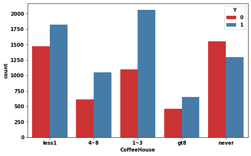

```python
plt.figure(figsize=[8,5])
ax = sns.countplot(x="CoffeeHouse", hue="Y", data=df3, palette="Set1")
plt.show()
```

```python
df3[["CoffeeHouse","Y"]].groupby(["CoffeeHouse","Y"]).size().groupby(level=[0]).apply(lambda x: np.round(x/x.sum(),2))
```

```
CoffeeHouse  Y
1~3          0    0.35
             1    0.65
4~8          0    0.37
             1    0.63
gt8          0    0.42
             1    0.58
less1        0    0.45
             1    0.55
never        0    0.54
             1    0.46
dtype: float64
```

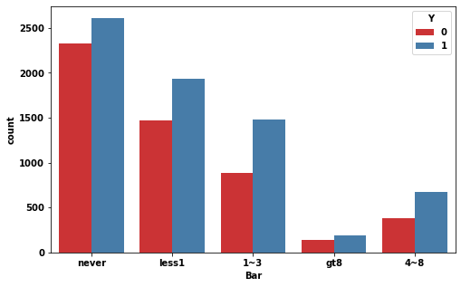

```python
plt.figure(figsize=[8,5])
ax = sns.countplot(x="Bar", hue="Y", data=df3, palette="Set1")
plt.show()
```

```python
df3[["Bar","Y"]].groupby(["Bar","Y"]).size().groupby(level=[0]).apply(lambda x: np.round(x/x.sum(),2))
```

```
Bar    Y
1~3    0    0.38
       1    0.62
4~8    0    0.36
       1    0.64
gt8    0    0.43
       1    0.57
less1  0    0.43
       1    0.57
never  0    0.47
       1    0.53
dtype: float64
```

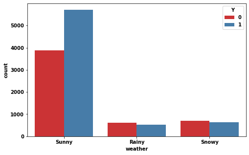

```python
plt.figure(figsize=[8,5])
ax = sns.countplot(x="weather", hue="Y", data=df3, palette="Set1")
plt.show()
```

```python
df3[["weather","Y"]].groupby(["weather","Y"]).size().groupby(level=[0]).apply(lambda x: np.round(x/x.sum(),2))
```

```
weather  Y
Rainy    0    0.54
         1    0.46
Snowy    0    0.52
         1    0.48
Sunny    0    0.40
         1    0.60
dtype: float64
```

From the above chart and percentage value, we can say that when weather is "Sunny" coupon has more chance of being accepted compared to "Rainy" and "snowy" weather.

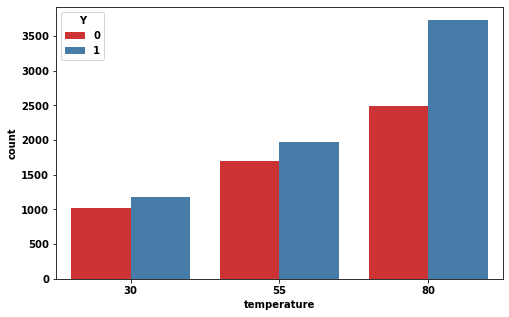

```python
plt.figure(figsize=[8,5])
ax = sns.countplot(x="temperature", hue="Y", data=df3, palette="Set1")
plt.show()
```

```python
df3[["temperature","Y"]].groupby(["temperature","Y"]).size().groupby(level=[0]).apply(lambda x: np.round(x/x.sum(),2))
```

```
temperature  Y
30           0    0.46
             1    0.54
55           0    0.46
             1    0.54
80           0    0.40
             1    0.60
dtype: float64
```

From the above chart and percentage value, we can say that in "80" degree temperature coupon has more chance of being accepted compared to "55" or "30" temperature.

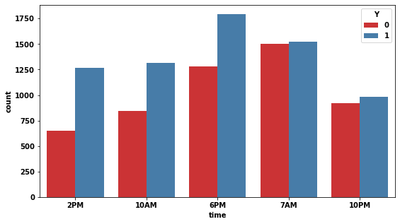

```python
plt.figure(figsize=[9,5])
ax = sns.countplot(x="time", hue="Y", data=df3, palette="Set1")
plt.show()
```

```python
df3[["time","Y"]].groupby(["time","Y"]).size().groupby(level=[0]).apply(lambda x: np.round(x/x.sum(),2))
```

```
time  Y
10AM  0    0.39
      1    0.61
10PM  0    0.48
      1    0.52
2PM   0    0.34
      1    0.66
6PM   0    0.42
      1    0.58
7AM   0    0.50
      1    0.50
dtype: float64
```

Early in the day (7AM) it has less chance for coupons getting accepted. Maybe people are rushing in the morning to go to work. After work they are more free or not rushing and therefore they are more likely to be accepting a coupon. However at 10PM they maybe tired, want to get home and less likely to accept the coupon.

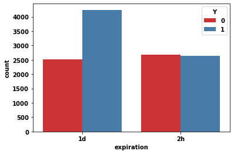

```python
plt.figure(figsize=[6,4])
ax = sns.countplot(x="expiration", hue="Y", data=df3, palette="Set1")
plt.show()
```

```python
df3[["expiration","Y"]].groupby(["expiration","Y"]).size().groupby(level=[0]).apply(lambda x: np.round(x/x.sum(),2))
```

```
expiration  Y
1d          0    0.37
            1    0.63
2h          0    0.50
            1    0.50
dtype: float64
```

Expiry time has a great influence on whether coupons will be accepted or not, as we can see from the chart "1" day has a lot higher chance of being accepted than in "2" hours.

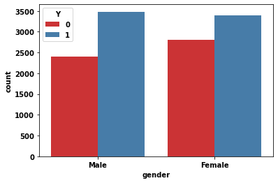

```python
plt.figure(figsize=[6,4])
ax = sns.countplot(x="gender", hue="Y", data=df3, palette="Set1")
plt.show()
```

```python
df3[["gender","Y"]].groupby(["gender","Y"]).size().groupby(level=[0]).apply(lambda x: np.round(x/x.sum(),2))
```

```
gender  Y
Female  0    0.45
        1    0.55
Male    0    0.41
        1    0.59
dtype: float64
```

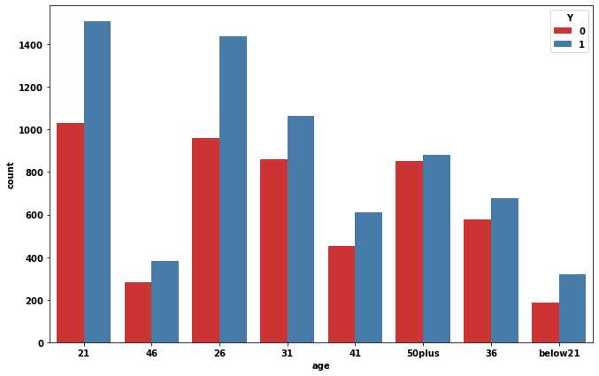

```python
plt.figure(figsize=[11,7])
ax = sns.countplot(x="age", hue="Y", data=df3, palette="Set1")
plt.show()
```

```python
df3[["age","Y"]].groupby(["age","Y"]).size().groupby(level=[0]).apply(lambda x: np.round(x/x.sum(),2))
```

```
age      Y
21       0    0.41
         1    0.59
26       0    0.40
         1    0.60
31       0    0.45
         1    0.55
36       0    0.46
         1    0.54
41       0    0.43
         1    0.57
46       0    0.42
         1    0.58
50plus   0    0.49
         1    0.51
below21  0    0.37
         1    0.63
dtype: float64
```

The younger age demographic will generally accept the coupon more often.

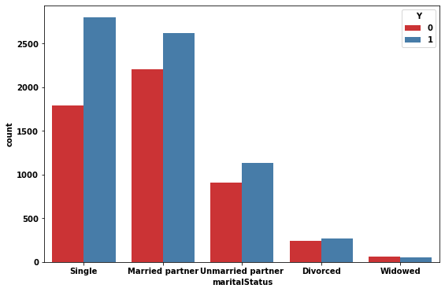

```python
plt.figure(figsize=[9,6])
ax = sns.countplot(x="maritalStatus", hue="Y", data=df3, palette="Set1")
plt.show()
```

```python
df3[["maritalStatus","Y"]].groupby(["maritalStatus","Y"]).size().groupby(level=[0]).apply(lambda x: np.round(x/x.sum(),2))
```

```
maritalStatus      Y
Divorced           0    0.47
                   1    0.53
Married partner    0    0.46
                   1    0.54
Single             0    0.39
                   1    0.61
Unmarried partner  0    0.44
                   1    0.56
Widowed            0    0.53
                   1    0.47
dtype: float64
```

Single people will accept the coupon more often then other martial status

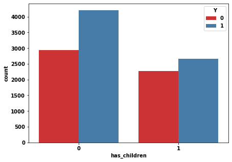

```python
plt.figure(figsize=[7,5])
ax = sns.countplot(x="has_children", hue="Y", data=df3, palette="Set1")
plt.show()
```

```python
df3[["has_children","Y"]].groupby(["has_children","Y"]).size().groupby(level=[0]).apply(lambda x: np.round(x/x.sum(),2))
```

```
has_children  Y
0             0    0.41
              1    0.59
1             0    0.46
              1    0.54
dtype: float64
```

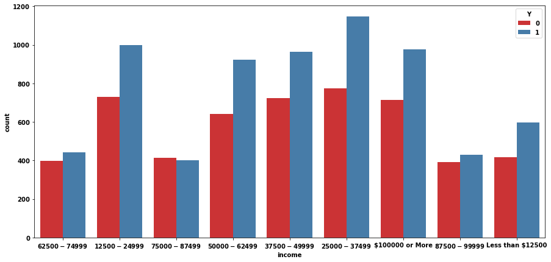

```python
plt.figure(figsize=[15,7])
ax = sns.countplot(x="income", hue="Y", data=df3, palette="Set1")
plt.show()
```

```python
df3[["income","Y"]].groupby(["income","Y"]).size().groupby(level=[0]).apply(lambda x: np.round(x/x.sum(),2))
```

```
income            Y
$100000 or More   0    0.42
                  1    0.58
$12500 - $24999   0    0.42
                  1    0.58
$25000 - $37499   0    0.40
                  1    0.60
$37500 - $49999   0    0.43
                  1    0.57
$50000 - $62499   0    0.41
                  1    0.59
$62500 - $74999   0    0.47
                  1    0.53
$75000 - $87499   0    0.51
                  1    0.49
$87500 - $99999   0    0.48
                  1    0.52
Less than $12500  0    0.41
                  1    0.59
dtype: float64
```

Generally, people in lower income bracket seems to have higher chance of accepting the coupon, compare to middle income. People in highest income bracket are also accepting coupon at higher rate.

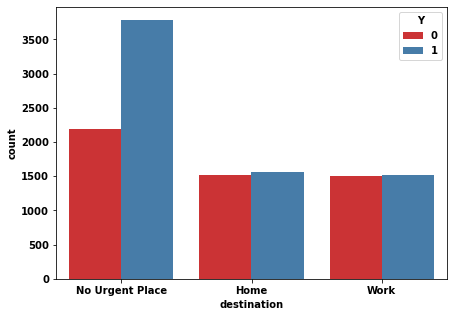

```python
plt.figure(figsize=[7,5])
ax = sns.countplot(x="destination", hue="Y", data=df3, palette="Set1")
plt.show()
```

```python
df3[["destination","Y"]].groupby(["destination","Y"]).size().groupby(level=[0]).apply(lambda x: np.round(x/x.sum(),2))
```

```
destination      Y
Home             0    0.49
                 1    0.51
No Urgent Place  0    0.37
                 1    0.63
Work             0    0.50
                 1    0.50
dtype: float64
```

When people don't have to be somewhere at specific time or aren't rushing then they will accept the coupon more often.

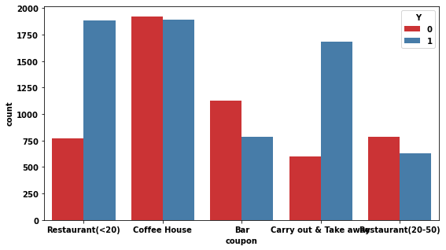

```python
plt.figure(figsize=[9,5])
ax = sns.countplot(x="coupon", hue="Y", data=df3, palette="Set1")
plt.show()
```

```python
df3[["coupon","Y"]].groupby(["coupon","Y"]).size().groupby(level=[0]).apply(lambda x: np.round(x/x.sum(),2))
```

```
coupon                 Y
Bar                    0    0.59
                       1    0.41
Carry out & Take away  0    0.26
                       1    0.74
Coffee House           0    0.50
                       1    0.50
Restaurant(20-50)      0    0.55
                       1    0.45
Restaurant(<20)        0    0.29
                       1    0.71
dtype: float64
```

People will accept coupon more often for places where they don't have to spend lot's of money and or more likely to go often.

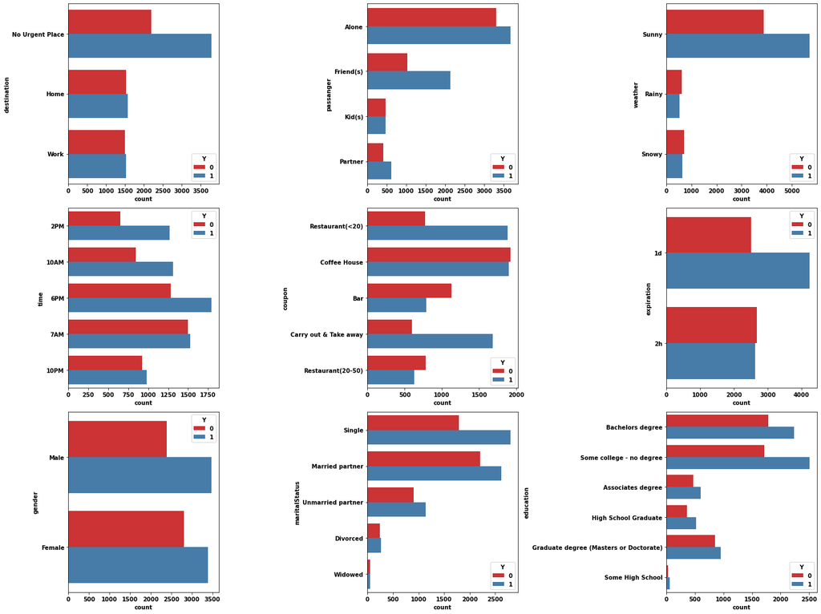

```python
fig, axes = plt.subplots(3, 3, figsize=(20, 15))
axes = axes.flatten()

for ax, col in zip(axes, ['destination', 'passanger', 'weather', 'time',
                          'coupon', 'expiration', 'gender', 'maritalStatus',
                          'education']):
    sns.countplot(y=col, hue='Y', data=df3, ax=ax, palette='Set1')
plt.tight_layout()
plt.show()
```

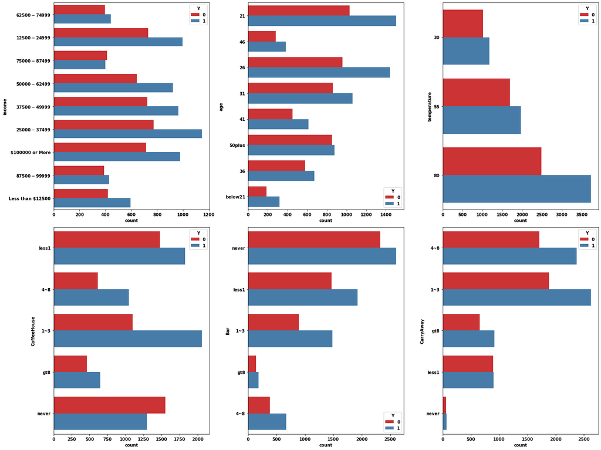

```python
fig, axes = plt.subplots(2, 3, figsize=(20, 15))
axes = axes.flatten()

for ax, col in zip(axes, ['income','age','temperature','CoffeeHouse','Bar','CarryAway']):
    sns.countplot(y=col, hue='Y', data=df3, ax=ax, palette='Set1')
plt.tight_layout()
plt.show()
```

Next, there were a few variables that were categorical in nature, but had some form of order, ie. they were ordinal variables. Ordinal variables in the dataset included time, age, income, Restaurant20to50, RestaurantLessThan20, CarryAway, CoffeeHouse, Bar, education, and temperature. These were transformed into numeric values based on their order. For example, 7AM was the earliest time so it was assigned 0, while 10AM was the next chronologic time stamp so it was assigned 1.

Doing both of these operations was necessary not only in terms of logical sense, but it also meant that not as many dummy variables would be needed for analysis. instead of needing 5 different dummy variables for time, only one column was needed after the transformation.

```python
df3.loc[df3.time == '7AM', 'time'] = 0 #replace 7am with 0
df3.loc[df3.time == '10AM', 'time'] = 1
df3.loc[df3.time == '2PM', 'time'] = 2
df3.loc[df3.time == '6PM', 'time'] = 3
df3.loc[df3.time == '10PM', 'time'] = 4
```

```python
df3.loc[df3.maritalStatus == 'Unmarried partner', 'maritalStatus'] = 'Unmarried' #grouping similar classes together
df3.loc[df3.maritalStatus == 'Divorced', 'maritalStatus'] = 'Unmarried'
df3.loc[df3.maritalStatus == 'Widowed', 'maritalStatus'] = 'Unmarried'
```

```python
df3.loc[df3.age == 'below21', 'age'] = 0
df3.loc[df3.age == '21', 'age'] = 1
df3.loc[df3.age == '26', 'age'] = 2
df3.loc[df3.age == '31', 'age'] = 3
df3.loc[df3.age == '36', 'age'] = 4
df3.loc[df3.age == '41', 'age'] = 5
df3.loc[df3.age == '46', 'age'] = 6
df3.loc[df3.age == '50plus', 'age'] = 7
```

```python
df3.loc[df3.income == 'Less than $12500', 'income'] = 0
df3.loc[df3.income == '$12500 - $24999', 'income'] = 1
df3.loc[df3.income == '$25000 - $37499', 'income'] = 2

df3.loc[df3.income == '$37500 - $49999', 'income'] = 3
df3.loc[df3.income == '$50000 - $62499', 'income'] = 4
df3.loc[df3.income == '$62500 - $74999', 'income'] = 5

df3.loc[df3.income == '$75000 - $87499', 'income'] = 6
df3.loc[df3.income == '$87500 - $99999', 'income'] = 7
df3.loc[df3.income == '$100000 or More', 'income'] = 8
```

```python
df3.loc[df3.Restaurant20To50 == 'never', 'Restaurant20To50'] = 0
df3.loc[df3.Restaurant20To50 == 'less1', 'Restaurant20To50'] = 1
df3.loc[df3.Restaurant20To50 == '1~3', 'Restaurant20To50'] = 2
df3.loc[df3.Restaurant20To50 == '4~8', 'Restaurant20To50'] = 3
df3.loc[df3.Restaurant20To50 == 'gt8', 'Restaurant20To50'] = 4
```

```python
df3.loc[df3.RestaurantLessThan20 == 'never', 'RestaurantLessThan20'] = 0
df3.loc[df3.RestaurantLessThan20 == 'less1', 'RestaurantLessThan20'] = 1
df3.loc[df3.RestaurantLessThan20 == '1~3', 'RestaurantLessThan20'] = 2
df3.loc[df3.RestaurantLessThan20 == '4~8', 'RestaurantLessThan20'] = 3
df3.loc[df3.RestaurantLessThan20 == 'gt8', 'RestaurantLessThan20'] = 4
```

```python
df3.loc[df3.CarryAway == 'never', 'CarryAway'] = 0
df3.loc[df3.CarryAway == 'less1', 'CarryAway'] = 1
df3.loc[df3.CarryAway == '1~3', 'CarryAway'] = 2
df3.loc[df3.CarryAway == '4~8', 'CarryAway'] = 3
df3.loc[df3.CarryAway == 'gt8', 'CarryAway'] = 4
```

```python
df3.loc[df3.CoffeeHouse == 'never', 'CoffeeHouse'] = 0
df3.loc[df3.CoffeeHouse == 'less1', 'CoffeeHouse'] = 1
df3.loc[df3.CoffeeHouse == '1~3', 'CoffeeHouse'] = 2
df3.loc[df3.CoffeeHouse == '4~8', 'CoffeeHouse'] = 3
df3.loc[df3.CoffeeHouse == 'gt8', 'CoffeeHouse'] = 4
```

```python
df3.loc[df3.Bar == 'never', 'Bar'] = 0
df3.loc[df3.Bar == 'less1', 'Bar'] = 1
df3.loc[df3.Bar == '1~3', 'Bar'] = 2
df3.loc[df3.Bar == '4~8', 'Bar'] = 3
df3.loc[df3.Bar == 'gt8', 'Bar'] = 4
```

```python
df3.loc[df3.education == 'Some High School', 'education'] = 0
df3.loc[df3.education == 'High School Graduate', 'education'] = 1
df3.loc[df3.education == 'Some college - no degree', 'education'] = 2
df3.loc[df3.education == 'Associates degree', 'education'] = 3
df3.loc[df3.education == 'Bachelors degree', 'education'] = 4
df3.loc[df3.education == 'Graduate degree (Masters or Doctorate)', 'education'] = 5
```

```python
df3.loc[df3.temperature == 30 , 'temperature'] = 0
df3.loc[df3.temperature == 55 , 'temperature'] = 1
df3.loc[df3.temperature == 80 , 'temperature'] = 2
```

```python
df3 #overview of new data
```

|  | destination | passanger | weather | temperature | time | coupon | expiration | gender | age | maritalStatus | ... | Bar | CoffeeHouse | CarryAway | RestaurantLessThan20 | Restaurant20To50 | toCoupon_GEQ15min | toCoupon_GEQ25min | direction_same | direction_opp | Y |
| --- | --- | --- | --- | --- | --- | --- | --- | --- | --- | --- | --- | --- | --- | --- | --- | --- | --- | --- | --- | --- | --- |
| 22 | No Urgent Place | Alone | Sunny | 1 | 2 | Restaurant(<20) | 1d | Male | 1 | Single | ... | 0 | 1 | 3 | 3 | 1 | 0 | 0 | 0 | 1 | 1 |
| 23 | No Urgent Place | Friend(s) | Sunny | 2 | 1 | Coffee House | 2h | Male | 1 | Single | ... | 0 | 1 | 3 | 3 | 1 | 0 | 0 | 0 | 1 | 0 |
| 24 | No Urgent Place | Friend(s) | Sunny | 2 | 1 | Bar | 1d | Male | 1 | Single | ... | 0 | 1 | 3 | 3 | 1 | 0 | 0 | 0 | 1 | 1 |
| 25 | No Urgent Place | Friend(s) | Sunny | 2 | 1 | Carry out & Take away | 2h | Male | 1 | Single | ... | 0 | 1 | 3 | 3 | 1 | 1 | 0 | 0 | 1 | 0 |
| 26 | No Urgent Place | Friend(s) | Sunny | 2 | 2 | Coffee House | 1d | Male | 1 | Single | ... | 0 | 1 | 3 | 3 | 1 | 0 | 0 | 0 | 1 | 0 |
| ... | ... | ... | ... | ... | ... | ... | ... | ... | ... | ... | ... | ... | ... | ... | ... | ... | ... | ... | ... | ... | ... |
| 12679 | Home | Partner | Rainy | 1 | 3 | Carry out & Take away | 1d | Male | 2 | Single | ... | 0 | 0 | 2 | 3 | 2 | 0 | 0 | 1 | 0 | 1 |
| 12680 | Work | Alone | Rainy | 1 | 0 | Carry out & Take away | 1d | Male | 2 | Single | ... | 0 | 0 | 2 | 3 | 2 | 0 | 0 | 0 | 1 | 1 |
| 12681 | Work | Alone | Snowy | 0 | 0 | Coffee House | 1d | Male | 2 | Single | ... | 0 | 0 | 2 | 3 | 2 | 0 | 0 | 1 | 0 | 0 |
| 12682 | Work | Alone | Snowy | 0 | 0 | Bar | 1d | Male | 2 | Single | ... | 0 | 0 | 2 | 3 | 2 | 1 | 1 | 0 | 1 | 0 |
| 12683 | Work | Alone | Sunny | 2 | 0 | Restaurant(20-50) | 2h | Male | 2 | Single | ... | 0 | 0 | 2 | 3 | 2 | 0 | 0 | 1 | 0 | 0 |

12079 rows × 24 columns

# Dummy Variables

Dummy variables were created for the remaining categorical variables to prepare the data for feature selection and model building. X (data) and y (target) variables were created to prepare for the train/test split.

```python
df4=pd.get_dummies(df3, columns = ['destination','passanger','weather','coupon',
                       'expiration','gender','maritalStatus',
                       'occupation'
                       ]) #get dummy vars for these columns
```

```python
df4.shape #new data shape
```

```
(12079, 63)
```

```python
X=df4.drop(['Y'],axis=1) #drop target
y=df4['Y'] #everything but target
```

# Train/Test split

Scaling was considered and tested for this data. However, because there is no drastic difference in the values of each column, this is not necessary. Standard Scaler was used and tried on the data, but did not make any changes to any of the results. The data used in the following models is unscaled due to these reasons.

```python
from sklearn.model_selection import train_test_split
X_train, X_test, y_train, y_test = train_test_split(X, y, test_size=0.2, random_state=27) #80/20 train/test split
```